# Using MR-Base

2016-01-12

## Introduction

Two sample Mendelian randomisation (2SMR) is a method to estimate the causal effect of an exposure on an outcome using only summary statistics from genome wide association studies (GWAS). The MR-Base package aims to make this easy by combining two important components - the statistical routines to estimate the causal effects, and a database comprising GWAS summary statistics from studies.

## Exposure data

You can read in exposure data from a text file, or from the GWAS catalog.

### Text file

The text file must have the following columns (in any order) with these exact column headers

- `SNP` (rs IDs, required)
- `beta` (numeric effect size, required for MR)
- `se` (numeric standard error, required for MR)
- `effect_allele` (the allele that has the beta effect, required for MR)
- `other_allele` (the other allele, recommended for MR)
- `eaf` (effect allele frequency, recommended for MR)
- `P_value` (p-value of effect, not required for MR but used for other analyses. If `beta` and `se` are provided then this will be calculated for you.)

We provide three example files in the package, one for telomere length, one for bladder cancer, and one for coronary heart disease. After installing the package you can find their locations on your computer like this:

```r
tl_file <- system.file("data/telomere_length.txt", package="TwoSampleMR")
bc_file <- system.file("data/bladdercancer.txt", package="TwoSampleMR")
chd_file <- system.file("data/cardiogram.txt", package="TwoSampleMR")
```

To read in the data:

```r
library(TwoSampleMR)
library(pander)
tl <- read_exposure_data(tl_file, "Telomere length")
```

```
## All necessary columns present for MR analysis
```

The function looks up the rs IDs in biomart to validate them and retrieve chromosome and position information.

### GWAS catalog

The GWAS catalog (http://www.ebi.ac.uk/gwas/) is a collection of 22271 reported associations against 1411 traits. These have the potential to be used as instruments in 2SMR. We have downloaded the GWAS catalog and made important formatting changes in order to simplify usage of these data for MR. **Please note that the reformatting of this data may be unreliable**.

To use the GWAS catalog:

```r
data(gwas_catalog)
```

and to extract, e.g. the instruments for BMI using the (Speliotes et al. 2010) SNPs:

```r
bmi <- subset(gwas_catalog, Phenotype=="Body mass index" & Year==2010 & grepl("kg", Units))
bmi <- format_gwas_catalog(bmi)
```

```
## All necessary columns present for MR analysis
```

### Data within R

You can create the expoure data object using data already in R also. e.g.

```r
manual_exposure <- data.frame(
    SNP = c("rs10150332", "rs10767664"),
    beta = c(0.13, 0.19),
    se = c(0.03061224, 0.03061224),
    effect_allele = c("C", "A"),
    other_allele = c("T", "T"),
    eaf = c(0.21, 0.78),
    P_value = c(3e-11, 5e-26)
)
manual_exposure <- format_exposure_dat(manual_exposure, "BMI")
```

```
## All necessary columns present for MR analysis
```

## LD pruning

For most 2SMR methods it is required that the instruments are in linkage equilibrium. To prune the SNPs we recommend using the clumping method which, when having to choose which of two SNPs to eliminate if they are in LD, will keep the one with the lowest p-value. There are two methods to do this, using either your own reference data and local computer, or using the MR-Base server remotely.

### Using MR-Base

This is currently limited to using European samples from 1000 genomes data only. You must provide a data frame that has a P-value column, SNP name, SNP position and SNP chromosome. The output from `read_exposure_data` has all of these.

```r
tl <- clump_data(tl)
```

```
## Removing the following SNPs due to LD with other SNPs:
## rs10936599
## rs10936601
## rs1317082
## rs1975174
## rs2487999
## rs4387287
## rs8105767
## rs9419958
```

```r
bmi <- clump_data(bmi)
```

This returns the same data frame with any SNPs in LD removed.

### Local LD pruning

You need to obtain the executable for plink2, and binary plink files for your reference data, e.g. 1000 genomes data.

```r
bmi <- clump_data(bmi, where="local", refdat="/path/to/reference_data", plink_bin="/path/to/plink2")
```

## Outcome data

Ideally for every SNP in your exposure data you will have the corresponding summary statistics from a GWAS on the outcome trait. There are two ways in which this data can be entered into R: by performing a lookup in the MR-Base database, or manually using your own summary statistics.

### MR-Base lookup

To see a list of all the available GWAS studies in the database:

```r
ao <- available_outcomes()
nrow(ao)
```

```
## [1] 41
```

```r
pander(head(ao))
```

Table continues below

| cat | consortium | ethnic |
| --- | --- | --- |
| disease | AMDGene | mixed |
| disease | AMDGene | mixed |
| disease | AMDGene | mixed |
| disease | CKDGen | Caucasian |
| disease | diagram | mixed |
| disease | gabriel | Caucasian |

Table continues below

| filename | gender | id |
| --- | --- | --- |
| AMDGene2013_Advanced_v_Controls.txt.gz.uniform.af.txt | both gender | 1 |
| AMDGene2013_GeographicAtropy_v_Controls.txt.gz.uniform.af.txt | both gender | 2 |
| AMDGene2013_Neovascular_v_Controls.txt.gz.uniform.af.txt | both gender | 3 |
| CKDGen-CKD_meta_post.csv.uniform.af.txt | both gender | 5 |
| diagram.mega-meta.txt.uniform.af.txt | both gender | 6 |
| gabriel_results.txt.uniform.af.txt | both gender | 7 |

Table continues below

| ncase | ncontrol | note |
| --- | --- | --- |
| 7650 | 51844 | GWAS is in standard normal units (inverse normal transformation); SD is to help guide interpretation but is only approximate |
| NA | NA |  |
| 4529 | 51844 |  |
| 5807 | 56430 |  |
| NA | NA |  |
| 8730 | 11389 |  |

Table continues below

| path | pmid | priority |
| --- | --- | --- |
| /projects/MRC-IEU/publicdata/GWAS_summary_data/AMDGC | 23455636 | 1 |
| /projects/MRC-IEU/publicdata/GWAS_summary_data/AMDGC | 23455636 | 2 |
| /projects/MRC-IEU/publicdata/GWAS_summary_data/AMDGC | 23455636 | 3 |
| /projects/MRC-IEU/publicdata/GWAS_summary_data/CKDGEN | 20383146 | 1 |
| /projects/MRC-IEU/publicdata/GWAS_summary_data/DIAGRAM | 24509480 | 1 |
| /projects/MRC-IEU/publicdata/GWAS_summary_data/Gabriel | 17611496 | 1 |

Table continues below

| public | sample_size | sd | subcat |
| --- | --- | --- | --- |
| public | 59494 | NA | autoimmune |
| public | 48550 | NA | autoimmune |
| public | 56373 | NA | autoimmune |
| public | 62237 | NA | kidney |
| conditional public | 110452 | NA | cardiovascular |
| public | 20119 | NA | autoimmune |

| trait | trait_strict | unit | year |
| --- | --- | --- | --- |
| Age related macular degeneration, Advanced AMD vs. Control | Age related macular degeneration | NA | 2013 |
| Age related macular degeneration, Geographic Atrophy vs. Control | Age related macular degeneration | NA | 2013 |
| Age related macular degeneration, Neovascular Disease vs. Control | Age related macular degeneration | NA | 2013 |
| Chronic kidney disease | Chronic kidney disease | log odds | 2010 |
| T2D | T2D | NA | 2014 |
| asthma | asthma | NA | 2007 |

and to extract the BMI SNPs from the Celiac disease and T2D GWASs provide the relevant exposure data and outcome IDs:

```r
outcome_dat <- extract_outcome_data(bmi, c(13, 6))
```

```
## Extracting data for 32 SNP(s) from 2 GWAS(s)
```

The resulting data frame has the following columns:

```r
names(outcome_dat)
```

```
##  [1] "SNP"                   "beta.outcome"
##  [3] "se.outcome"            "samplesize.outcome"
##  [5] "ncase.outcome"         "ncontrol.outcome"
##  [7] "pval.outcome"          "eaf.outcome"
##  [9] "effect_allele.outcome" "other_allele.outcome"
## [11] "outcome"               "consortium.outcome"
## [13] "year.outcome"          "pmid.outcome"
## [15] "id.outcome"            "displayname.outcome"
```

### Manual

Alternatively, create a data frame with the following columns:

- `beta.outcome` (Numeric effect sizes, required)
- `se.outcome` (Numeric standard errors, required)
- `eaf.outcome` (Numeric frequency of the effect allele, recommended)
- `effect_allele.outcome` (Effect allele, required)
- `other_allele.outcome` (Other allele, recommended)
- `outcome` (Name of the outcome, required)

## Harmonising exposure and outcome data

In order to ensure that the effect sizes in the exposure data correspond to the same allele effects in the outcome data it is necessary to check and harmonise these data. We provide a function that ensures all corresponding exposure and outcome alleles are on the same strand (where possible), and returns a harmonised dataset.

```r
bmi_outcome <- harmonise_exposure_outcome(bmi, outcome_dat, action = 2)
```

```
## [1] 31  2 11
## integer(0)
```

The `action` argument specifies how strict to be when checking for the correct strand:

- `1` means assume that all alleles are on the positive strand already (not recommended!)
- `2` means flip alleles where possible, and use allele frequencies to infer the strand of palindromic SNPs.
- `3` means flip alleles where possible but remove any palindromic SNPs

## Performing 2SMR

The data is now ready to perform 2-sample MR. To do this:

```r
mr_results <- mr(bmi_outcome)
```

[output not shown]

This performs MR using the following different available methods:

```r
pander(mr_method_list())
```

Table continues below

| obj | name | PubmedID |
| --- | --- | --- |
| mr_wald_ratio | Wald ratio |  |
| mr_meta_fixed_simple | Fixed effects meta analysis (simple SE) |  |
| mr_meta_fixed | Fixed effects meta analysis (delta method) |  |
| mr_meta_random | Random effects meta analysis (delta method) |  |
| mr_two_sample_ml | Maximum likelihood |  |
| mr_eggers_regression | MR Egger regression |  |
| mr_eggers_regression_bootstrap | MR Egger regression (bootstrap) |  |
| mr_weighted_median | Weighted median |  |
| mr_penalised_weighted_median | Penalised weighted median |  |
| mr_ivw | Inverse variance weighted regression |  |

| Description |
| --- |

### Sensitivity analysis

To see how different methods compare:

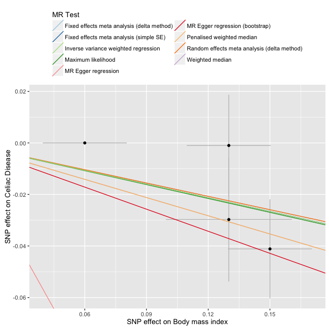

```r
mr_scatter_plot(mr_results, bmi_outcome)[[2]]
```

To compare the effects of each of the SNPs we can generate a forest plot, e.g. for BMI on T2D:

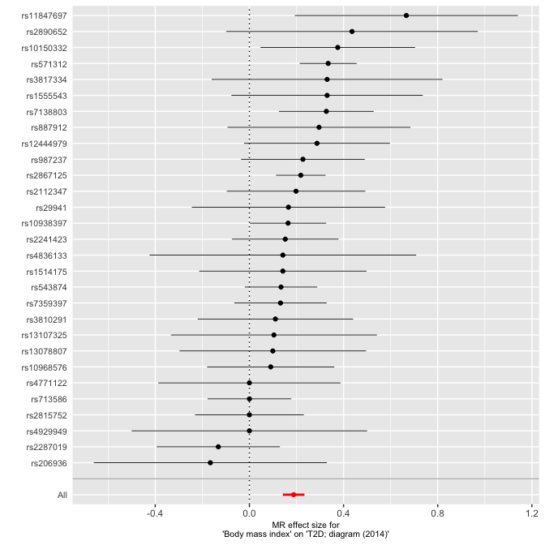

```r
s <- mr_singlesnp(bmi_outcome)
mr_forest_plot(s)[[2]]
```

And to perform a leave-one-out sensitivity analysis:

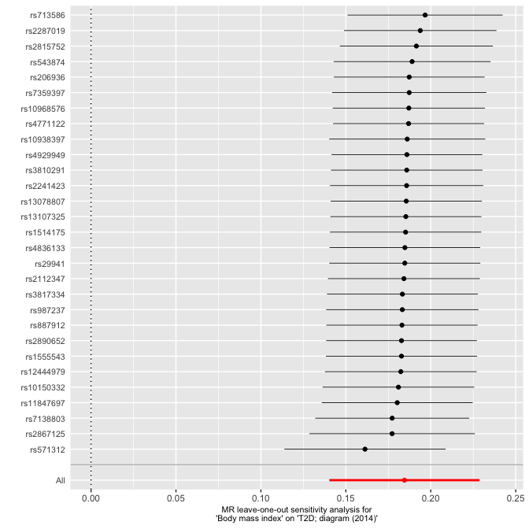

```r
l <- mr_leaveoneout(bmi_outcome)
mr_leaveoneout_plot(l)[[2]]
```

References

Bowden, Jack, George Davey Smith, and Stephen Burgess. 2015. “Mendelian randomization with invalid instruments: effect estimation and bias detection through Egger regression.” *International Journal of Epidemiology* In press.

Smith, George Davey, Gibran Hemani, G. Davey Smith, and Gibran Hemani. 2014. “Mendelian randomization: genetic anchors for causal inference in epidemiological studies.” *Human Molecular Genetics* 23 (R1). Oxford Univ Press: R89—–98. doi:10.1093/hmg/ddu328.

Speliotes, Elizabeth K, Cristen J Willer, Sonja I Berndt, Keri L Monda, Gudmar Thorleifsson, Anne U Jackson, Hana Lango Allen, et al. 2010. “Association analyses of 249,796 individuals reveal 18 new loci associated with body mass index.” *Nature Genetics* 42 (11): 937–48. doi:10.1038/ng.686.